# Final

Hwang Seong-Yun

2020 12 23

## (A) The denim dataset (faraway package) concerns the amount of waste in material cutting for a jeans manufacturer due to five suppliers.

```r
library(faraway)
data(denim)
```

- waste : percentage wastage (%)
- supplier : a factor with levels 1 2 3 4 5

### 1. Plot the data and comment.

```r
summary(denim)
```

```
##      waste         supplier
##  Min.   :-11.600   1:22
##  1st Qu.:  2.550   2:22
##  Median :  5.200   3:19
##  Mean   :  6.977   4:19
##  3rd Qu.:  9.950   5:13
##  Max.   : 70.200
```

- 변수 waste는 청바지 제작 시 낭비되는 재료의 비율을 나타내고, 변수 supplier는 5가지의 공급업체를 나타내는 factor 변수이다. 자료를 살펴보기 위해 boxplot을 그려보면 다음과 같다.

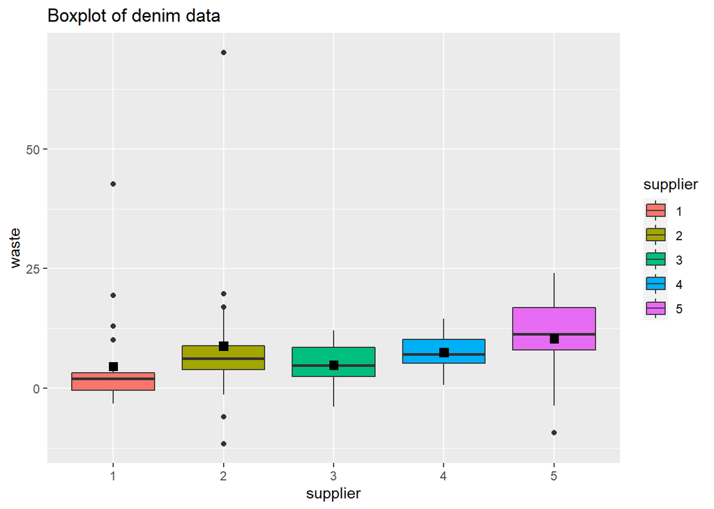

```r
library(ggplot2)
ggplot(data=denim, aes(x=supplier, y=waste, fill=supplier)) +
  geom_boxplot() +
  stat_summary(fun="mean", geom="point", shape=22, size=3, fill="black") +
  ggtitle("Boxplot of denim data")
```

- Boxplot을 통해서 볼 때 5번 공급업체의 재료낭비비율에 대한 분산이 가장 큰 것으로 보여진다. 하지만, 이상치는 공급업체 1과 2에서 두드러지게 나타나고 있다. 그리고 재료낭비비율에 대한 평균은 공급업체 1이 가장 낮게 나타나고 있다.

### 2. Fit the linear fixed effects model. Is the operator significant?

- 분석을 위해 다음과 같은 fixed effects model을 가정한다.
- $y _{ij} = \mu + \alpha _{i} + \epsilon _{ij}$
- $\epsilon _{ij} ->iid N(0, \sigma ^{2} )$

```r
lmod <- lm(waste ~ supplier, data=denim)
anova(lmod)
```

```
## Analysis of Variance Table
##
## Response: waste
##           Df Sum Sq Mean Sq F value Pr(>F)
## supplier   4  450.9 112.730  1.1596  0.334
## Residuals 90 8749.1  97.212
```

- 모형적합 결과, 유의확률이 0.334이므로 유의수준 0.05보다 크다. 이에 따라 공급업체에 따른 재료낭비비율의 차이가 유의하지 않다고 말할 수 있다.

### 3. Make a useful diagnostic plot for this model and comment.

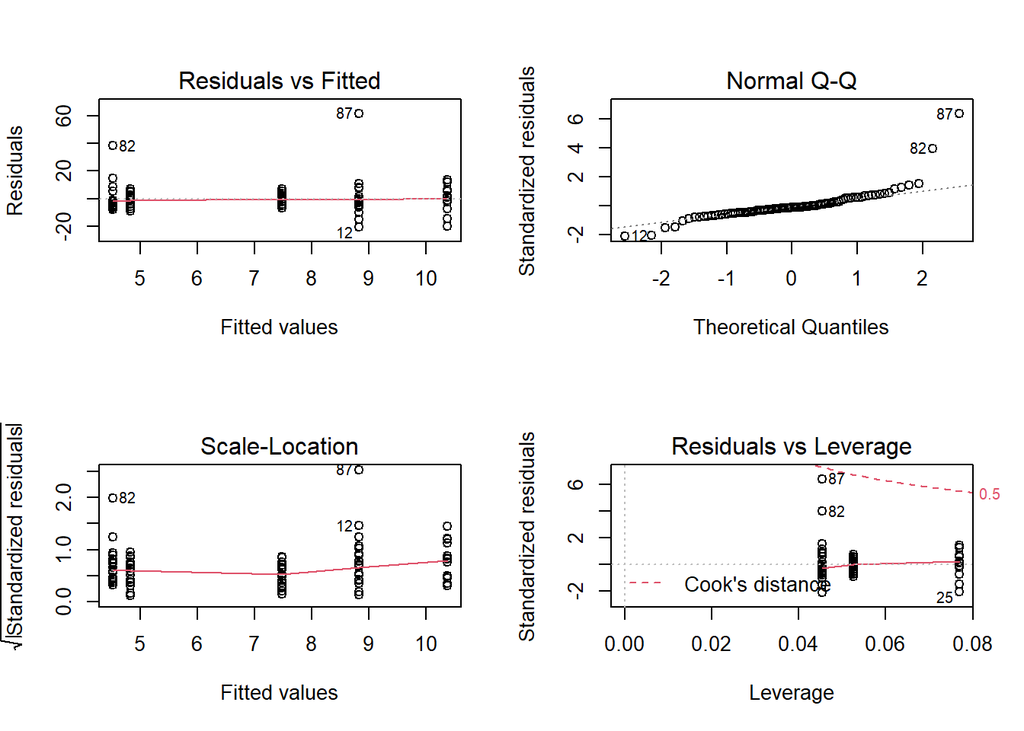

```r
par(mfrow=c(2,2))
plot(lmod)
```

```r
par(mfrow=c(1,1))
```

- 모형에 대한 검진그래프를 통해 잔차의 정규성이 의심되는 것을 확인할 수 있다. 또한 잔차에 대한 등분산성이나 독립성도 위배되는 것으로 보이며 이상치도 다수 존재함을 확인가능하다.

### 4. Analyze the data with supplier as a random effect. What are the estimated standard deviations of the effects?

- 분석을 위해 다음과 같은 random effects model을 가정한다.
- $y _{ij} = \mu + \alpha _{i} + \epsilon _{ij}$
- $\epsilon _{ij} ->iid N(0, \sigma ^{2} )$
- $\alpha _{i} -> N(0, \sigma _{\alpha }^{2} )$

```r
library(lme4)
lmod1 <- lmer(waste ~ (1 | supplier), data = denim)
summary(lmod1)
```

```
## Linear mixed model fit by REML ['lmerMod']
## Formula: waste ~ (1 | supplier)
##    Data: denim
##
## REML criterion at convergence: 702.1
##
## Scaled residuals:
##     Min      1Q  Median      3Q     Max
## -1.9095 -0.4363 -0.1669  0.3142  6.3817
##
## Random effects:
##  Groups   Name        Variance Std.Dev.
##  supplier (Intercept)  0.6711  0.8192
##  Residual             97.3350  9.8658
## Number of obs: 95, groups:  supplier, 5
##
## Fixed effects:
##             Estimate Std. Error t value
## (Intercept)    6.997      1.078    6.49
```

- 위의 결과를 통해서 estimated standard deviations of the effects의 값은 $sqrt {0.6711} = 0.8192069$ 임을 확인할 수 있다.

### 5. Test the significance of the supplier term.

### 6. Compute confidence intervals for the random effect SDs.

```r
confint(lmod1, oldNames = FALSE)
```

```
## Computing profile confidence intervals ...
```

```
##                            2.5 %    97.5 %
## sd_(Intercept)|supplier 0.000000  4.206374
## sigma                   8.591567 11.424996
## (Intercept)             4.977790  8.975895
```

- 위의 결과에서 ${\hat{\sigma _{\alpha }}}$에 대한 95% 신뢰구간에 0이 포함되어 있으므로 공급업체에 대한 term이 유의하다고 볼 수는 없다.
- 그리고 random effect SDs에 대한 95% 신뢰구간은 (0 , 4.2064)임을 추가로 확인할 수 있다.

### 7. Estimate the effect of each supplier. If only one supplier will be used, choose the best.

- 각 공급업체별 효과는 다음을 통해 추정할 수 있다.

```r
summary(lmod)
```

```
##
## Call:
## lm(formula = waste ~ supplier, data = denim)
##
## Residuals:
##     Min      1Q  Median      3Q     Max
## -20.432  -4.377  -1.323   2.639  61.368
##
## Coefficients:
##             Estimate Std. Error t value Pr(>|t|)
## (Intercept)   4.5227     2.1021   2.152   0.0341 *
## supplier2     4.3091     2.9728   1.450   0.1507
## supplier3     0.3089     3.0879   0.100   0.9206
## supplier4     2.9667     3.0879   0.961   0.3392
## supplier5     5.8542     3.4491   1.697   0.0931 .
## ---
## Signif. codes:  0 '***' 0.001 '**' 0.01 '*' 0.05 '.' 0.1 ' ' 1
##
## Residual standard error: 9.86 on 90 degrees of freedom
## Multiple R-squared:  0.04901,    Adjusted R-squared:  0.006747
## F-statistic:  1.16 on 4 and 90 DF,  p-value: 0.334
```

- 위의 결과를 통해 공급업체 1에 비해 공급업체 2는 4.3091%, 공급업체 3은 0.3089%, 공급업체 4는 2.9667%, 공급업체는 5.8542% 재료낭비비율이 높게 추정됨을 확인할 수 있다. 이에 따라 재료낭비비율이 가장 적게 추정되는 공급업체 1을 선택하는 것이 현명하다.

## (B) Data on the butterfat content of milk from Canadian cows of five different breeds and two different ages can be found in the butterfat dataset (faraway package).

```r
library(faraway)
data(butterfat)
summary(butterfat)
```

```
##    Butterfat                  Breed        Age
##  Min.   :3.300   Ayrshire        :20   2year :50
##  1st Qu.:3.938   Canadian        :20   Mature:50
##  Median :4.405   Guernsey        :20
##  Mean   :4.482   Holstein-Fresian:20
##  3rd Qu.:4.987   Jersey          :20
##  Max.   :6.550
```

- Butterfat : butter fat content by percentage
- Breed : a factor with levels Ayrshire Canadian Guernsey Holstein-Fresian Jersey
- Age : a factor with levels 2year Mature

### 1. Make appropriate plots of the data and make your guess on the extistence of an interaction effect between breed and age.

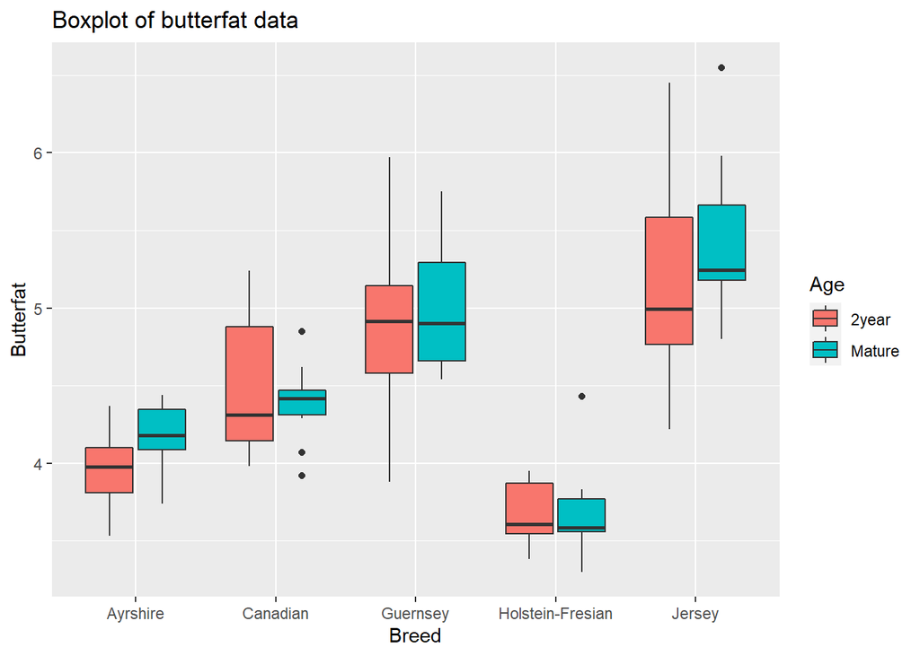

```r
library(ggplot2)
ggplot(data=butterfat, aes(x=Breed, y=Butterfat, fill=Age)) +
  geom_boxplot() +
  ggtitle("Boxplot of butterfat data")
```

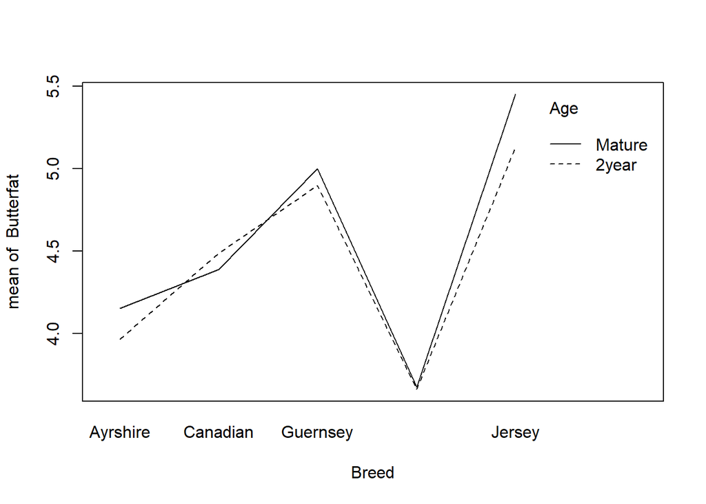

```r
with(butterfat, interaction.plot(x.factor = Breed, trace.factor = Age, response = Butterfat))
```

- 위의 Boxplot과 interaction plot을 통해서 변수 Breed와 변수 Age 사이에는 교호작용 효과가 거의 없는 것으로 파악할 수 있다. Age에 따른 Butterfat~Breed 그래프의 증감이 거의 비슷하기 때문이다.

### 2. Find and fit a reasonable regression model with butterfat content as response. Is the best breed in terms of butterfat content clearly superior to the second best breed?

- 문제 1의 결과를 바탕으로 상호작용 효과가 없는 모형을 고려한다. 다만 Breed의 경우는 소의 종과 관련된 만큼 임의로 선택(random effect)했다는 가정 하에 다음과 같은 Mixed effect model을 가정한다.
- $y _{ijk} = \mu + \alpha _{i} + \beta _{j} + \epsilon _{ijk}$
- $\epsilon _{ijk} ->iid N(0, \sigma ^{2} )$
- $\alpha _{i} -> N(0, \sigma _{\alpha }^{2} )$

```r
fit <- lmer(Butterfat ~ (1 | Breed) + Age, data = butterfat)
summary(fit)
```

```
## Linear mixed model fit by REML ['lmerMod']
## Formula: Butterfat ~ (1 | Breed) + Age
##    Data: butterfat
##
## REML criterion at convergence: 128.6
##
## Scaled residuals:
##     Min      1Q  Median      3Q     Max
## -2.4370 -0.5811 -0.1665  0.6167  2.9629
##
## Random effects:
##  Groups   Name        Variance Std.Dev.
##  Breed    (Intercept) 0.4205   0.6484
##  Residual             0.1712   0.4138
## Number of obs: 100, groups:  Breed, 5
##
## Fixed effects:
##             Estimate Std. Error t value
## (Intercept)  4.42980    0.29583  14.974
## AgeMature    0.10460    0.08276   1.264
##
## Correlation of Fixed Effects:
##           (Intr)
## AgeMature -0.140
```

```r
confint(fit, oldNames = FALSE)
```

```
## Computing profile confidence intervals ...
```

```
##                            2.5 %    97.5 %
## sd_(Intercept)|Breed  0.33795176 1.2731688
## sigma                 0.35934422 0.4778524
## (Intercept)           3.79629365 5.0633068
## AgeMature            -0.05838729 0.2675873
```